# Mutation frequency analysis

Barbara Arbeithuber and Marzia A. Cremona

# Data preparation and correlation plot

```r
library(ggplot2)
library(reshape2)
library(plyr)
library(readxl)
require(lme4)
require(MuMIn)
require(multcomp)
```

Remove sites: 255 G>C (because of insertion - microsatellite) 273 C>A (end of read) 11022 A>C (beginning of polyA - coupled with deletion of a A) 297 A>C (beginning of polyC - coupled with insertion of a C) 13750 A>C (in polyC stretch) 11029 A>C (in polyC stretch)

```r
mut2 <- read_excel("2020-09_Rh_mut_freqs.xlsx", sheet = "Rh_mut_freq")
head(mut2, n=2)
```

| sample_name | macaque_ID | HiSeq_run_ID | tissue | age_years | age_group | het_sites_macaque | het_sites_sample | primate_center | Oo_total | Oo_seq | Oo_seq (depth>100x) | size | morphology | buffer | PE_reads | DCS total | DCS mtDNA | percent_mtDNA | SSCS total | SSCS mtDNA | mean_depth_DCS | nt_sequenced | nt_DL | nt_NC | nt_NC_nDL | nt_out_DL | nt_protein | nt_rRNA | nt_tRNA | … |
| --- | --- | --- | --- | --- | --- | --- | --- | --- | --- | --- | --- | --- | --- | --- | --- | --- | --- | --- | --- | --- | --- | --- | --- | --- | --- | --- | --- | --- | --- | --- |
| Rh015_Li | Rh015 | DS06 | liver | 19.7 | old | 0 | 0 | WI_NPRC | 9 | 2 | 2 | - | - | - | 7882436 | 173874 | 160431 | 0.9226854 | 887275 | 811184 | 1008 | 16696512 | 1093680 | 1223712 | 130032 | 15602832 | 11460960 | 2525040 | 1516032 | … |
| Rh015_M | Rh015 | DS06_DS08 | muscle | 19.7 | old | 0 | 0 | WI_NPRC | 9 | 2 | 2 | - | - | - | 16733992 | 730355 | 643112 | 0.8805471 | 2822487 | 2442270 | 3820 | 63274480 | 4144700 | 4637480 | 492780 | 59129780 | 43433400 | 9569100 | 5745280 | … |

```r
nrow(mut2)
```

```
[1] 221
```

```r
# select only samples with depth >= 100x
mut <- subset(mut2, mean_depth_DCS >= 100)
nrow(mut)
```

```
[1] 188
```

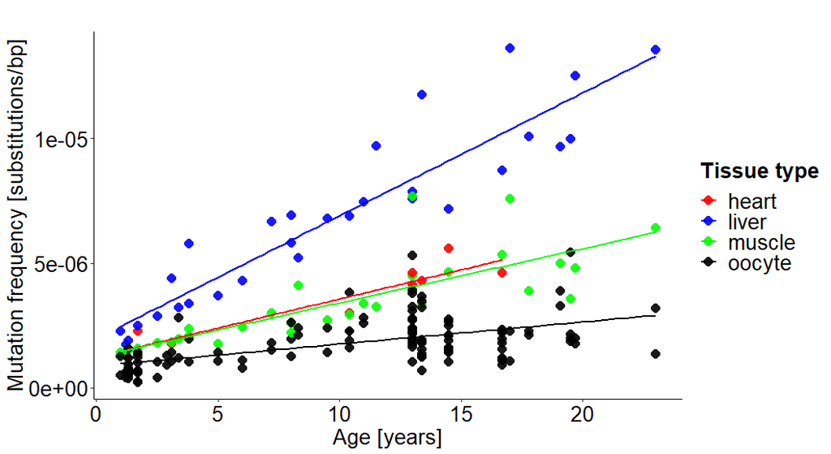

```r
options(repr.plot.width=11, repr.plot.height=6)

p <- ggplot(mut, aes(x=age_years, y=(n_mutations/nt_sequenced), color=tissue)) +
  geom_point(shape=16, size=4, alpha=0.9) +
  geom_smooth(method=lm, formula= y~x, se = FALSE) +
  scale_color_manual(values=c("red","blue", "green", "black")) +
# scale_y_continuous(limits = c(0, 0.0000034),breaks=c(seq(0,0.0000034,0.0000005))) +
  theme_classic() +
  labs(title="",x="Age [years]",y="Mutation frequency [substitutions/bp]") +
# scale_fill_manual(values=c("red","navy","grey","grey20"), labels=c("Brain", "Skeletal muscle", "Oocyte", "Oocyte pool")) +
# scale_color_manual(values=c("red","navy","grey","grey20"), labels=c("Brain", "Skeletal muscle", "Oocyte", "Oocyte pool")) +
  theme(axis.text.x = element_text(size=20, color="black"),axis.text.y = element_text(size=20, color="black"), axis.title.x = element_text(size=20), axis.title.y = element_text(size=20)) +
  guides(color=guide_legend(title="Tissue type")) +
  theme(legend.text=element_text(size=20)) +
  theme(legend.title=element_text(size=20, face="bold")) +
  theme(plot.title = element_text(size=20, lineheight=.8, face="bold", hjust = 0.5))

ggsave(filename="2020-10-14_mut_freq_d100.pdf", plot=p, , width = 11, height = 6)

p
```

# Mixed-effects linear model

Transform in factor (set muscle as baseline tissue), rescale age_years

```r
mut$tissue = factor(mut$tissue, levels = c('muscle', 'heart', 'liver', 'oocyte'))
mut$macaque_ID = as.factor(mut$macaque_ID)
mut$age_years_scaled = as.numeric(scale(mut$age_years))
```

Model Age vs Mutation frequency taking into consideration tissue type (fixed effect) and individual (random effect). Note: in a binomial model prior weights (`weights = nt_sequenced`) are used to give the number of trials when the response is the proportion of successes (`mut_freq`):

```r
glmer_results <- glmer(mut_freq ~ age_years_scaled*tissue + (1|macaque_ID),
                       weights = nt_sequenced, family = binomial(link = "logit"),
                       control=glmerControl(optimizer="bobyqa", optCtrl = list(maxfun = 10000)),
                       data = mut)
summary(glmer_results)
```

```
Generalized linear mixed model fit by maximum likelihood (Laplace Approximation) ['glmerMod']
 Family: binomial  ( logit )
Formula: mut_freq ~ age_years_scaled * tissue + (1 | macaque_ID)
   Data: mut
Weights: nt_sequenced
Control: glmerControl(optimizer = "bobyqa", optCtrl = list(maxfun = 10000))

     AIC      BIC   logLik deviance df.resid
  1608.0   1637.1   -795.0   1590.0      179

Scaled residuals:
    Min      1Q  Median      3Q     Max
-3.9340 -0.7108  0.2204  1.3058  5.5141

Random effects:
 Groups     Name        Variance Std.Dev.
 macaque_ID (Intercept) 0.03478  0.1865
Number of obs: 188, groups:  macaque_ID, 30

Fixed effects:
                               Estimate Std. Error  z value Pr(>|z|)
(Intercept)                   -12.74810    0.03721 -342.572  < 2e-16 ***
age_years_scaled                0.42181    0.03687   11.439  < 2e-16 ***
tissueheart                     0.02652    0.03675    0.721   0.4706
tissueliver                     0.71223    0.01890   37.692  < 2e-16 ***
tissueoocyte                   -0.71804    0.02990  -24.013  < 2e-16 ***
age_years_scaled:tissueheart    0.11433    0.04995    2.289   0.0221 *
age_years_scaled:tissueliver    0.08347    0.01919    4.350 1.36e-05 ***
age_years_scaled:tissueoocyte  -0.12707    0.02987   -4.254 2.10e-05 ***
---
Signif. codes:  0 ‘***’ 0.001 ‘**’ 0.01 ‘*’ 0.05 ‘.’ 0.1 ‘ ’ 1

Correlation of Fixed Effects:
                 (Intr) ag_yr_ tsshrt tsslvr tsscyt ag_yrs_scld:tssh ag_yrs_scld:tssl
ag_yrs_scld      -0.009
tissueheart      -0.160  0.027
tissueliver      -0.309  0.062  0.309
tissueoocyt      -0.214  0.051  0.254  0.398
ag_yrs_scld:tssh  0.016 -0.133 -0.343 -0.025  0.020
ag_yrs_scld:tssl  0.061 -0.315 -0.052 -0.266 -0.083  0.202
ag_yrs_scld:tssc  0.046 -0.229 -0.030 -0.082 -0.216  0.256            0.400
```

Coefficients transforming back `age_years` to the original scale:

```r
beta_model = summary(glmer_results)$coefficients[,1]
mu = mean(mut$age_years)
sigma = sd(mut$age_years)
beta_rescaled_back = beta_model
beta_rescaled_back[c(2,6:8)] = beta_model[c(2,6:8)]/sigma
beta_rescaled_back[c(1,3:5)] = beta_model[c(1,3:5)] - beta_model[c(2,6:8)]*mu/sigma

as.matrix(beta_rescaled_back)
```

```
                                      [,1]
(Intercept)                   -13.41444647
age_years_scaled                0.06669249
tissueheart                    -0.15410021
tissueliver                     0.58036834
tissueoocyte                   -0.51729545
age_years_scaled:tissueheart    0.01807743
age_years_scaled:tissueliver    0.01319740
age_years_scaled:tissueoocyte  -0.02009178
```

Odds ratio:

```r
odds_ratio = exp(beta_rescaled_back)
odds_ratio[1] = NA
as.matrix(odds_ratio)
```

```
                                   [,1]
(Intercept)                          NA
age_years_scaled              1.0689667
tissueheart                   0.8571861
tissueliver                   1.7866964
tissueoocyte                  0.5961306
age_years_scaled:tissueheart  1.0182418
age_years_scaled:tissueliver  1.0132849
age_years_scaled:tissueoocyte 0.9801087
```

Check residuals

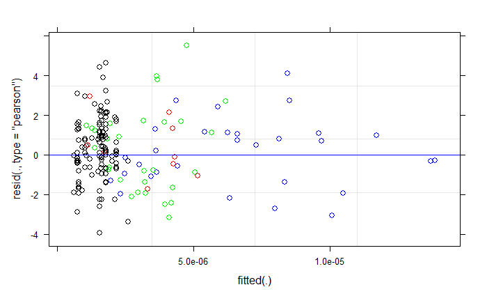

```r
plot(glmer_results, col=c("green", "red", "blue", "black")[mut$tissue])
```

Compute pseudo_R2

```r
glmer_null <- glmer(mut_freq ~ (1|macaque_ID),
                    weights = nt_sequenced, family = binomial(link = "logit"),
                    control=glmerControl(optimizer="bobyqa", optCtrl = list(maxfun = 10000)),
                    data = mut)

r.squaredGLMM(glmer_results, null = glmer_null)
```

```
'r.squaredGLMM' now calculates a revised statistic. See the help page.
```

```
                     R2m          R2c
theoretical 1.121003e-01 1.213899e-01
delta       1.674765e-06 1.813551e-06
```

```r
r2_full <- r.squaredGLMM(glmer_results, null = glmer_null)[1,1]
r2_full
```

```
[1] 0.1121003
```

## Test random effect

Test random effect macaque_ID

```r
glmer_red <- glm(mut_freq ~ age_years_scaled*tissue,
                 weights = nt_sequenced, family = binomial(link = "logit"),
                 data = mut)
anova(glmer_results, glmer_red)
```

```
Data: mut
Models:
glmer_red: mut_freq ~ age_years_scaled * tissue
glmer_results: mut_freq ~ age_years_scaled * tissue + (1 | macaque_ID)
              npar    AIC    BIC  logLik deviance Chisq Df Pr(>Chisq)
glmer_red        8 2012.8 2038.7 -998.39   1996.8
glmer_results    9 1608.0 1637.1 -794.99   1590.0 406.8  1  < 2.2e-16 ***
---
Signif. codes:  0 ‘***’ 0.001 ‘**’ 0.01 ‘*’ 0.05 ‘.’ 0.1 ‘ ’ 1
```

```r
anova(glmer_results, glmer_red)$`Pr(>Chisq)`
```

```
[1]           NA 1.823291e-90
```

Conditional modes of the random effects:

```r
ranef_macaque_ID = ranef(glmer_results)$macaque_ID[,1]
summary(ranef_macaque_ID)
```

```
      Min.    1st Qu.     Median       Mean    3rd Qu.       Max.
-0.3960441 -0.1468214  0.0181173  0.0009721  0.1421267  0.2914584
```

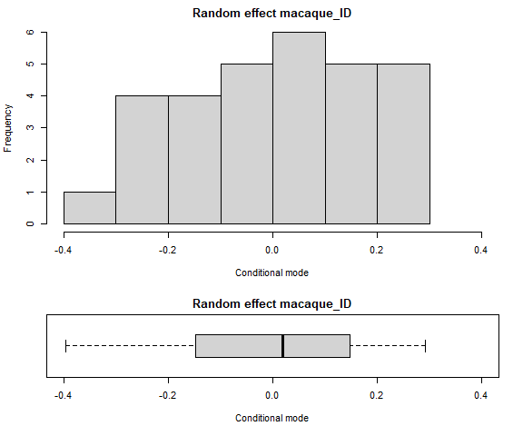

```r
layout(matrix(c(1,1,2), nrow = 3))
hist(ranef_macaque_ID, main = 'Random effect macaque_ID', xlab = 'Conditional mode', xlim = c(-0.4, 0.4))
boxplot(ranef_macaque_ID, main = 'Random effect macaque_ID', xlab = 'Conditional mode', horizontal = TRUE, ylim = c(-0.4, 0.4))
```

Test if a random effect primate_center would also be important

```r
glmer_center <- glmer(mut_freq ~ age_years_scaled*tissue + (1|macaque_ID) + (1|primate_center),
                      weights = nt_sequenced, family = binomial(link = "logit"),
                      control=glmerControl(optimizer="bobyqa", optCtrl = list(maxfun = 10000)),
                      data = mut)
anova(glmer_center, glmer_results)
```

```
Data: mut
Models:
glmer_results: mut_freq ~ age_years_scaled * tissue + (1 | macaque_ID)
glmer_center: mut_freq ~ age_years_scaled * tissue + (1 | macaque_ID) + (1 | primate_center)
              npar    AIC    BIC  logLik deviance  Chisq Df Pr(>Chisq)
glmer_results    9 1608.0 1637.1 -794.99   1590.0
glmer_center    10 1609.9 1642.2 -794.94   1589.9 0.1005  1     0.7512
```

It’s not important at all (once macaque_ID is included)

## Test fixed effects

Test effect of age_years

```r
glmer_red <- glmer(mut_freq ~ tissue + (1|macaque_ID),
                   weights = nt_sequenced, family = binomial(link = "logit"),
                   control=glmerControl(optimizer="bobyqa", optCtrl = list(maxfun = 10000)),
                   data = mut)
a=anova(glmer_results, glmer_red)
a$`Pr(>Chisq)`
```

```
[1]           NA 1.296853e-26
```

Partial R2

```r
r2 <- r.squaredGLMM(glmer_red, null=glmer_null)[1,1]
(r2_full - r2) / (1-r2) * 100
```

```
[1] 3.072584
```

Test effect of tissue

```r
glmer_red <- glmer(mut_freq ~ age_years_scaled + (1|macaque_ID),
                   weights = nt_sequenced, family = binomial(link = "logit"),
                   control=glmerControl(optimizer="bobyqa", optCtrl = list(maxfun = 10000)),
                   data = mut)
a=anova(glmer_results, glmer_red)
a$`Pr(>Chisq)`
```

```
[1] NA  0
```

Partial R2

```r
r2 <- r.squaredGLMM(glmer_red, null=glmer_null)[1,1]
(r2_full - r2) / (1-r2) * 100
```

```
[1] 4.998702
```

Test effect of different slopes for different tissues

```r
glmer_red <- glmer(mut_freq ~ age_years_scaled + tissue + (1|macaque_ID),
                   weights = nt_sequenced, family = binomial(link = "logit"),
                   control=glmerControl(optimizer="bobyqa", optCtrl = list(maxfun = 10000)),
                   data = mut)
a=anova(glmer_results, glmer_red)
a$`Pr(>Chisq)`
```

```
[1]           NA 5.171281e-15
```

Test effect of different intercepts for different tissues

```r
glmer_red <- glmer(mut_freq ~ age_years_scaled + age_years_scaled:tissue + (1|macaque_ID),
                   weights = nt_sequenced, family = binomial(link = "logit"),
                   control=glmerControl(optimizer="bobyqa", optCtrl = list(maxfun = 10000)),
                   data = mut)
a=anova(glmer_results, glmer_red)
a$`Pr(>Chisq)`
```

```
[1] NA  0
```

## Test slopes for different tissues

```r
coeffs_glmer = coeffs(glmer_results)
coeffs_glmer
```

```
                  (Intercept)              age_years_scaled                   tissueheart                   tissueliver                  tissueoocyte
                 -12.74810335                    0.42180615                    0.02651635                    0.71222722                   -0.71803801
 age_years_scaled:tissueheart  age_years_scaled:tissueliver age_years_scaled:tissueoocyte
                   0.11433326                    0.08346884                   -0.12707334
```

Test muscle slope:

```r
beta1 = coeffs_glmer[2]
beta1/sigma
```

```
age_years_scaled
      0.06669249
```

```r
K = matrix(0, nrow = 1, ncol = length(coeffs_glmer))
K[1,c(2)] = 1/sigma
colnames(K) = names(coeffs_glmer)
rownames(K) = "slope_muscle"
summary(glht(glmer_results, linfct = K))
```

```
     Simultaneous Tests for General Linear Hypotheses

Fit: glmer(formula = mut_freq ~ age_years_scaled * tissue + (1 | macaque_ID),
    data = mut, family = binomial(link = "logit"), control = glmerControl(optimizer = "bobyqa",
        optCtrl = list(maxfun = 10000)), weights = nt_sequenced)

Linear Hypotheses:
                  Estimate Std. Error z value Pr(>|z|)
slope_muscle == 0  0.06669    0.00583   11.44   <2e-16 ***
---
Signif. codes:  0 ‘***’ 0.001 ‘**’ 0.01 ‘*’ 0.05 ‘.’ 0.1 ‘ ’ 1
(Adjusted p values reported -- single-step method)
```

```r
2*pnorm(-summary(glht(glmer_results, linfct = K))$test$tstat)
```

```
slope_muscle
2.666239e-30
```

Test heart slope:

```r
beta1_5 = coeffs_glmer[2]+coeffs_glmer[6]
beta1_5/sigma
```

```
age_years_scaled
      0.08476992
```

```r
K = matrix(0, nrow = 1, ncol = length(coeffs_glmer))
K[1,c(2,6)] = 1/sigma
colnames(K) = names(coeffs_glmer)
rownames(K) = "slope_heart"
summary(glht(glmer_results, linfct = K))
```

```
     Simultaneous Tests for General Linear Hypotheses

Fit: glmer(formula = mut_freq ~ age_years_scaled * tissue + (1 | macaque_ID),
    data = mut, family = binomial(link = "logit"), control = glmerControl(optimizer = "bobyqa",
        optCtrl = list(maxfun = 10000)), weights = nt_sequenced)

Linear Hypotheses:
                 Estimate Std. Error z value Pr(>|z|)
slope_heart == 0 0.084770   0.009171   9.243   <2e-16 ***
---
Signif. codes:  0 ‘***’ 0.001 ‘**’ 0.01 ‘*’ 0.05 ‘.’ 0.1 ‘ ’ 1
(Adjusted p values reported -- single-step method)
```

```r
2*pnorm(-summary(glht(glmer_results, linfct = K))$test$tstat)
```

```
 slope_heart
2.397558e-20
```

Test liver slope:

```r
beta1_6 = coeffs_glmer[2]+coeffs_glmer[7]
beta1_6/sigma
```

```
age_years_scaled
      0.07988989
```

```r
K = matrix(0, nrow = 1, ncol = length(coeffs_glmer))
K[1,c(2,7)] = 1/sigma
colnames(K) = names(coeffs_glmer)
rownames(K) = "slope_liver"
summary(glht(glmer_results, linfct = K))
```

```
     Simultaneous Tests for General Linear Hypotheses

Fit: glmer(formula = mut_freq ~ age_years_scaled * tissue + (1 | macaque_ID),
    data = mut, family = binomial(link = "logit"), control = glmerControl(optimizer = "bobyqa",
        optCtrl = list(maxfun = 10000)), weights = nt_sequenced)

Linear Hypotheses:
                 Estimate Std. Error z value Pr(>|z|)
slope_liver == 0 0.079890   0.005663   14.11   <2e-16 ***
---
Signif. codes:  0 ‘***’ 0.001 ‘**’ 0.01 ‘*’ 0.05 ‘.’ 0.1 ‘ ’ 1
(Adjusted p values reported -- single-step method)
```

```r
2*pnorm(-summary(glht(glmer_results, linfct = K))$test$tstat)
```

```
 slope_liver
3.380584e-45
```

Test oocyte slope:

```r
beta1_7 = coeffs_glmer[2]+coeffs_glmer[8]
beta1_7/sigma
```

```
age_years_scaled
      0.04660071
```

```r
K = matrix(0, nrow = 1, ncol = length(coeffs_glmer))
K[1,c(2,8)] = 1/sigma
colnames(K) = names(coeffs_glmer)
rownames(K) = "slope_oocyte"
summary(glht(glmer_results, linfct = K))
```

```
     Simultaneous Tests for General Linear Hypotheses

Fit: glmer(formula = mut_freq ~ age_years_scaled * tissue + (1 | macaque_ID),
    data = mut, family = binomial(link = "logit"), control = glmerControl(optimizer = "bobyqa",
        optCtrl = list(maxfun = 10000)), weights = nt_sequenced)

Linear Hypotheses:
                  Estimate Std. Error z value Pr(>|z|)
slope_oocyte == 0 0.046601   0.006608   7.053 1.76e-12 ***
---
Signif. codes:  0 ‘***’ 0.001 ‘**’ 0.01 ‘*’ 0.05 ‘.’ 0.1 ‘ ’ 1
(Adjusted p values reported -- single-step method)
```

```r
2*pnorm(-summary(glht(glmer_results, linfct = K))$test$tstat)
```

```
slope_oocyte
1.755555e-12
```

## Plot model prediction

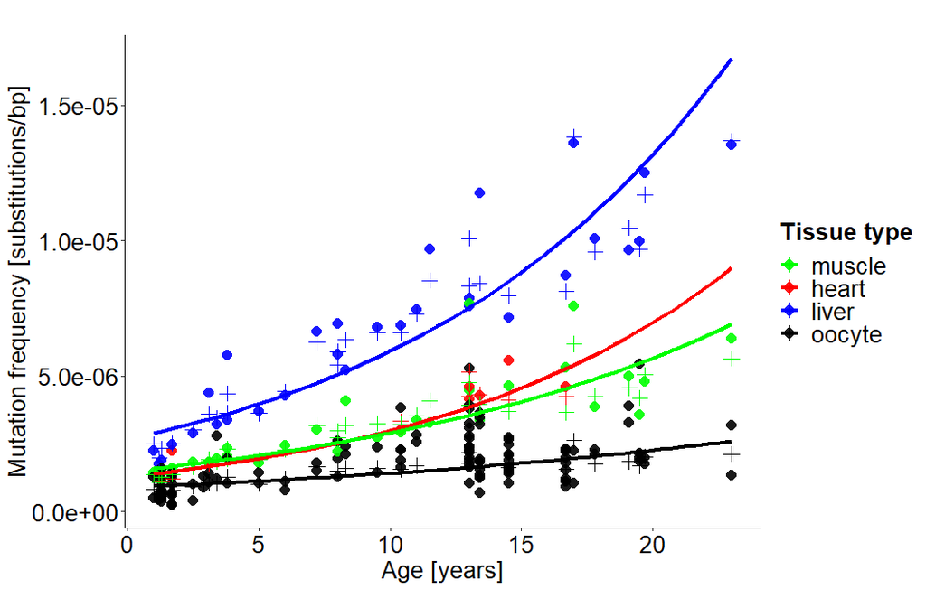

```r
options(repr.plot.width=11, repr.plot.height=7)

age_plot = seq(min(mut$age_years),max(mut$age_years),length.out = 50)
data_plot = data.frame(tissue = rep(levels(mut$tissue), each=50),
                       age_years = rep(age_plot, 4),
                       age_years_scaled = rep((age_plot-mean(mut$age_years))/sd(mut$age_years), 4))
data_plot$mut_freq = predict(glmer_results, data_plot, re.form=~0, type='response')

p <- ggplot(mut, aes(x=age_years, y=mut_freq, color=tissue)) +
  geom_point(shape=16, size=4, alpha=0.9) +
  scale_color_manual(values=c("green", "red","blue", "black")) +
  theme_classic() +
  labs(title="",x="Age [years]",y="Mutation frequency [substitutions/bp]") +
  theme(axis.text.x = element_text(size=20, color="black"),axis.text.y = element_text(size=20, color="black"), axis.title.x = element_text(size=20), axis.title.y = element_text(size=20)) +
  guides(color=guide_legend(title="Tissue type")) +
  theme(legend.text=element_text(size=20)) +
  theme(legend.title=element_text(size=20, face="bold")) +
  theme(plot.title = element_text(size=20, lineheight=.8, face="bold", hjust = 0.5)) +

  geom_point(mut, mapping = aes(x = age_years, y = fitted(glmer_results), color=tissue), shape = 3, size = 4) +
  geom_line(data_plot, mapping = aes(x = age_years, y = mut_freq, color=tissue), lwd = 1.5)

ggsave(filename="2021-03-08_mut_freq_d100_model_pred.pdf", plot=p, , width = 11, height = 7)

p
```

```r
age_plot = seq(min(mut$age_years),max(mut$age_years),length.out = 50)
data_plot = data.frame(tissue = rep(levels(mut$tissue), each=50),
                       age_years = rep(age_plot, 4),
                       age_years_scaled = rep((age_plot-mean(mut$age_years))/sd(mut$age_years), 4))
data_plot$mut_freq = predict(glmer_results, data_plot, re.form=~0, type='response')

# bootstrap for computing CI using quantile approach
predFun <- function(fit){
  predict(fit, data_plot, re.form=~0, type='response')
}
merBoot = bootMer(glmer_results, FUN=predFun, nsim=100)
CIlevel = 0.95
data_plot$mut_freq_CIlower = apply(merBoot$t, 2, function(x) as.numeric(quantile(x, probs=(1-CIlevel)/2, na.rm=TRUE)))
data_plot$mut_freq_CIupper = apply(merBoot$t, 2, function(x) as.numeric(quantile(x, probs=(1+CIlevel)/2, na.rm=TRUE)))
```

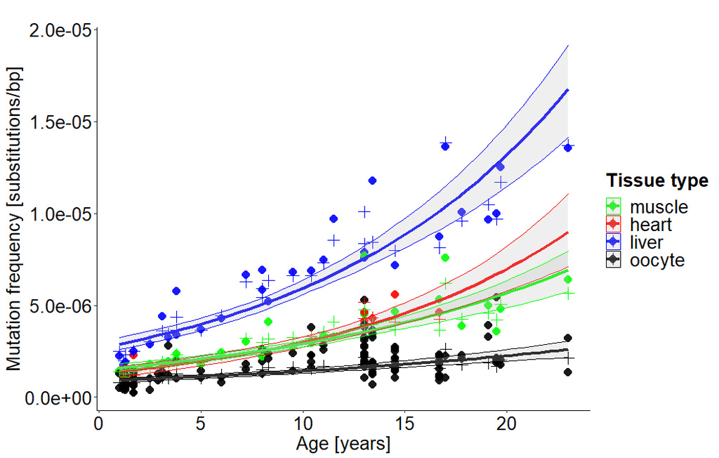

```r
options(repr.plot.width=11, repr.plot.height=7)

p <- ggplot(mut, aes(x=age_years, y=mut_freq, color=tissue)) +
  geom_point(shape=16, size=4, alpha=0.9) +
  scale_color_manual(values=c("green", "red","blue", "black")) +
  theme_classic() +
  labs(title="",x="Age [years]",y="Mutation frequency [substitutions/bp]") +
  theme(axis.text.x = element_text(size=20, color="black"),axis.text.y = element_text(size=20, color="black"), axis.title.x = element_text(size=20), axis.title.y = element_text(size=20)) +
  guides(color=guide_legend(title="Tissue type")) +
  theme(legend.text=element_text(size=20)) +
  theme(legend.title=element_text(size=20, face="bold")) +
  theme(plot.title = element_text(size=20, lineheight=.8, face="bold", hjust = 0.5)) +

  geom_point(mut, mapping = aes(x = age_years, y = fitted(glmer_results), color=tissue), shape = 3, size = 4) +
  geom_line(data_plot, mapping = aes(x = age_years, y = mut_freq, color=tissue), lwd = 1.5) +

  geom_ribbon(data_plot, mapping = aes(x=age_years, ymax=mut_freq_CIlower, ymin=mut_freq_CIupper), fill="gray", alpha=.25)

ggsave(filename="2021-12-23_mut_freq_d100_model_pred_CI.pdf", plot=p, , width = 11, height = 7)

p
```

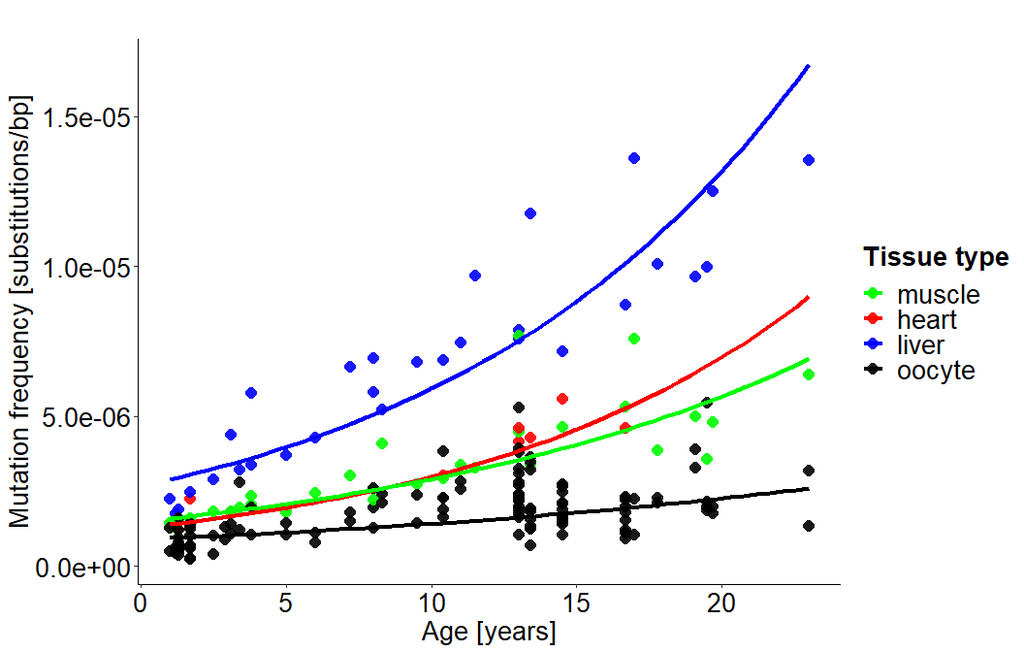

```r
options(repr.plot.width=11, repr.plot.height=7)

age_plot = seq(min(mut$age_years),max(mut$age_years),length.out = 50)
data_plot = data.frame(tissue = rep(levels(mut$tissue), each=50),
                       age_years = rep(age_plot, 4),
                       age_years_scaled = rep((age_plot-mean(mut$age_years))/sd(mut$age_years), 4))
data_plot$mut_freq = predict(glmer_results, data_plot, re.form=~0, type='response')

p <- ggplot(mut, aes(x=age_years, y=mut_freq, color=tissue)) +
  geom_point(shape=16, size=4, alpha=0.9) +
  scale_color_manual(values=c("green", "red","blue", "black")) +
  theme_classic() +
  labs(title="",x="Age [years]",y="Mutation frequency [substitutions/bp]") +
  theme(axis.text.x = element_text(size=20, color="black"),axis.text.y = element_text(size=20, color="black"), axis.title.x = element_text(size=20), axis.title.y = element_text(size=20)) +
  guides(color=guide_legend(title="Tissue type")) +
  theme(legend.text=element_text(size=20)) +
  theme(legend.title=element_text(size=20, face="bold")) +
  theme(plot.title = element_text(size=20, lineheight=.8, face="bold", hjust = 0.5)) +

  #geom_point(mut, mapping = aes(x = age_years, y = fitted(glmer_results), color=tissue), shape = 3, size = 4) +
  geom_line(data_plot, mapping = aes(x = age_years, y = mut_freq, color=tissue), lwd = 1.5)

ggsave(filename="2021-03-08_mut_freq_d100_model_pred_no_plus.pdf", plot=p, , width = 11, height = 7)

p
```

# Piecewise model only for oocytes, break chosen by AIC/BIC

Add a breakpoint at age=X (segmented regression) ONLY FOR OOCYTES, select X by AIC/BIC:

```r
age_break_try = 5:15

regression_break = function(age_break){
  age_break_scaled = (age_break-mean(mut$age_years))/sd(mut$age_years)
  mut$age_break_var = ( mut$age_years_scaled > age_break_scaled ) * ( mut$age_years_scaled - age_break_scaled ) * ( mut$tissue == "oocyte" )
  glmer_results_break <- glmer(mut_freq ~ age_years_scaled*tissue + age_break_var + (1|macaque_ID),
                               weights = nt_sequenced, family = binomial(link = "logit"),
                               control=glmerControl(optimizer="bobyqa", optCtrl = list(maxfun = 10000)),
                               data = mut)
  return(c(age_break, summary(glmer_results_break)$AICtab[1:2]))
}

break_results = Reduce(rbind, lapply(age_break_try, regression_break))
colnames(break_results) = c('age', 'AIC', 'BIC')
row.names(break_results) = NULL
break_results
```

```
      age      AIC      BIC
 [1,]   5 1591.778 1624.143
 [2,]   6 1590.548 1622.912
 [3,]   7 1589.555 1621.919
 [4,]   8 1587.611 1619.976
 [5,]   9 1586.993 1619.357
 [6,]  10 1587.612 1619.976
 [7,]  11 1590.133 1622.498
 [8,]  12 1594.600 1626.965
 [9,]  13 1598.990 1631.355
[10,]  14 1604.116 1636.481
[11,]  15 1607.813 1640.178
```

Best models:

```r
best_age = age_break_try[apply(break_results[,2:3], 2, which.min)]
names(best_age) = c('AIC', 'BIC')
best_age
```

```
AIC BIC
  9   9
```

Best model based on AIC and BIC has a break at years=9. Complete model:
$$E(Y)=\beta_0+\beta_1 age\_scaled+\beta_2H+\beta_3L+\beta_4O+\beta_5 I_{age>9} \times (age-9)\_scaled \times O+\beta_6 age\_scaled \times H+\beta_7 age\_scaled \times L+\beta_8 age\_scaled \times O$$

```r
age_break = 9
age_break_scaled = (age_break-mean(mut$age_years))/sd(mut$age_years)
mut$age_break_var = ( mut$age_years_scaled > age_break_scaled ) * ( mut$age_years_scaled - age_break_scaled ) * ( mut$tissue == "oocyte" )

glmer_results_break <- glmer(mut_freq ~ age_years_scaled*tissue + age_break_var + (1|macaque_ID),
                             weights = nt_sequenced, family = binomial(link = "logit"),
                             control=glmerControl(optimizer="bobyqa", optCtrl = list(maxfun = 10000)),
                             data = mut)
summary(glmer_results_break)
```

```
Generalized linear mixed model fit by maximum likelihood (Laplace Approximation) ['glmerMod']
 Family: binomial  ( logit )
Formula: mut_freq ~ age_years_scaled * tissue + age_break_var + (1 | macaque_ID)
   Data: mut
Weights: nt_sequenced
Control: glmerControl(optimizer = "bobyqa", optCtrl = list(maxfun = 10000))

     AIC      BIC   logLik deviance df.resid
  1587.0   1619.4   -783.5   1567.0      178

Scaled residuals:
    Min      1Q  Median      3Q     Max
-3.7559 -0.8133  0.2049  1.2274  5.8466

Random effects:
 Groups     Name        Variance Std.Dev.
 macaque_ID (Intercept) 0.02976  0.1725
Number of obs: 188, groups:  macaque_ID, 30

Fixed effects:
                               Estimate Std. Error  z value Pr(>|z|)
(Intercept)                   -12.74682    0.03488 -365.438  < 2e-16 ***
age_years_scaled                0.41800    0.03456   12.096  < 2e-16 ***
tissueheart                     0.02516    0.03668    0.686  0.49276
tissueliver                     0.71433    0.01888   37.833  < 2e-16 ***
tissueoocyte                   -0.43058    0.06588   -6.535 6.35e-11 ***
age_break_var                  -0.55572    0.11576   -4.800 1.58e-06 ***
age_years_scaled:tissueheart    0.12161    0.04955    2.454  0.01411 *
age_years_scaled:tissueliver    0.08010    0.01910    4.194 2.74e-05 ***
age_years_scaled:tissueoocyte   0.20057    0.07472    2.684  0.00727 **
---
Signif. codes:  0 ‘***’ 0.001 ‘**’ 0.01 ‘*’ 0.05 ‘.’ 0.1 ‘ ’ 1

Correlation of Fixed Effects:
                 (Intr) ag_yr_ tsshrt tsslvr tsscyt ag_br_ ag_yrs_scld:tssh ag_yrs_scld:tssl
ag_yrs_scld      -0.014
tissueheart      -0.171  0.028
tissueliver      -0.330  0.065  0.310
tissueoocyt      -0.097  0.003  0.107  0.203
age_brek_vr      -0.007  0.022  0.009 -0.024 -0.892
ag_yrs_scld:tssh  0.016 -0.142 -0.337 -0.025  0.032 -0.024
ag_yrs_scld:tssl  0.064 -0.333 -0.052 -0.264 -0.070  0.034  0.202
ag_yrs_scld:tssc  0.025 -0.116 -0.017 -0.011  0.775 -0.912  0.126            0.127
```

Coefficients transforming back `age_years` to the original scale:

```r
beta_model = summary(glmer_results_break)$coefficients[,1]
mu = mean(mut$age_years)
sigma = sd(mut$age_years)
beta_break_rescaled_back = beta_model
beta_break_rescaled_back[c(2,6,7:9)] = beta_model[c(2,6,7:9)]/sigma
beta_break_rescaled_back[c(1,3:5)] = beta_model[c(1,3:5)] - beta_model[c(2,7:9)]*mu/sigma

as.matrix(beta_break_rescaled_back)
```

```
                                      [,1]
(Intercept)                   -13.40714248
age_years_scaled                0.06609007
tissueheart                    -0.16695951
tissueliver                     0.58780150
tissueoocyte                   -0.74743310
age_break_var                  -0.08786549
age_years_scaled:tissueheart    0.01922863
age_years_scaled:tissueliver    0.01266408
age_years_scaled:tissueoocyte   0.03171320
```

Odds ratio:

```r
odds_ratio_break = exp(beta_break_rescaled_back)
odds_ratio_break[1] = NA
as.matrix(odds_ratio_break)
```

```
                                   [,1]
(Intercept)                          NA
age_years_scaled              1.0683229
tissueheart                   0.8462339
tissueliver                   1.8000267
tissueoocyte                  0.4735806
age_break_var                 0.9158841
age_years_scaled:tissueheart  1.0194147
age_years_scaled:tissueliver  1.0127446
age_years_scaled:tissueoocyte 1.0322214
```

Check residuals

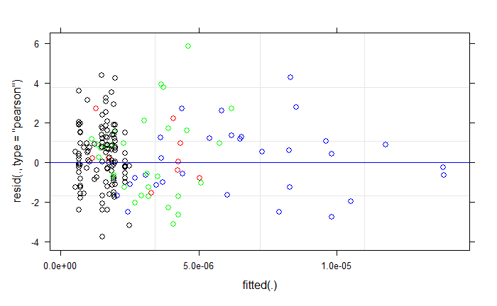

```r
plot(glmer_results_break, col=c("green", "red", "blue", "black")[mut$tissue])
```

Compute pseudo_R2

```r
r.squaredGLMM(glmer_results_break, null = glmer_null)
```

```
                     R2m          R2c
theoretical 1.178141e-01 1.257230e-01
delta       1.768852e-06 1.887595e-06
```

```r
r2_full_break <- r.squaredGLMM(glmer_results_break, null = glmer_null)[1,1]
r2_full_break
```

```
[1] 0.1178141
```

## Test difference with initial model

Test age_break_var

```r
anova(glmer_results_break, glmer_results)
```

```
Data: mut
Models:
glmer_results: mut_freq ~ age_years_scaled * tissue + (1 | macaque_ID)
glmer_results_break: mut_freq ~ age_years_scaled * tissue + age_break_var + (1 | macaque_ID)
                    npar  AIC    BIC  logLik deviance Chisq Df Pr(>Chisq)
glmer_results          9 1608 1637.1 -794.99     1590
glmer_results_break   10 1587 1619.4 -783.50     1567 22.98  1  1.637e-06 ***
---
Signif. codes:  0 ‘***’ 0.001 ‘**’ 0.01 ‘*’ 0.05 ‘.’ 0.1 ‘ ’ 1
```

```r
anova(glmer_results_break, glmer_results)$`Pr(>Chisq)`
```

```
[1]           NA 1.637074e-06
```

## Test random effect

Test random effect macaque_ID

```r
glmer_break_red <- glm(mut_freq ~ age_years_scaled*tissue + age_break_var,
                       weights = nt_sequenced, family = binomial(link = "logit"),
                       data = mut)
anova(glmer_results_break, glmer_break_red)
```

```
Data: mut
Models:
glmer_break_red: mut_freq ~ age_years_scaled * tissue + age_break_var
glmer_results_break: mut_freq ~ age_years_scaled * tissue + age_break_var + (1 | macaque_ID)
                    npar  AIC    BIC  logLik deviance  Chisq Df Pr(>Chisq)
glmer_break_red        9 1902 1931.2 -942.01     1884
glmer_results_break   10 1587 1619.4 -783.50     1567 317.03  1  < 2.2e-16 ***
---
Signif. codes:  0 ‘***’ 0.001 ‘**’ 0.01 ‘*’ 0.05 ‘.’ 0.1 ‘ ’ 1
```

```r
anova(glmer_results_break, glmer_break_red)$`Pr(>Chisq)`
```

```
[1]           NA 6.418453e-71
```

Conditional modes of the random effects:

```r
ranef_macaque_ID = ranef(glmer_results_break)$macaque_ID[,1]
summary(ranef_macaque_ID)
```

```
      Min.    1st Qu.     Median       Mean    3rd Qu.       Max.
-0.3725072 -0.1391736  0.0151935  0.0009479  0.1255293  0.2924945
```

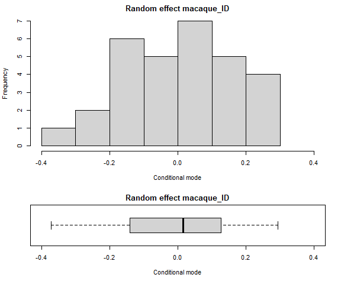

```r
layout(matrix(c(1,1,2), nrow = 3))
hist(ranef_macaque_ID, main = 'Random effect macaque_ID', xlab = 'Conditional mode', xlim = c(-0.4, 0.4))
boxplot(ranef_macaque_ID, main = 'Random effect macaque_ID', xlab = 'Conditional mode', horizontal = TRUE, ylim = c(-0.4, 0.4))
```

Test if a random effect primate_center would also be important

```r
glmer_break_center <- glmer(mut_freq ~ age_years_scaled*tissue + age_break_var + (1|macaque_ID) + (1|primate_center),
                            weights = nt_sequenced, family = binomial(link = "logit"),
                            control=glmerControl(optimizer="bobyqa", optCtrl = list(maxfun = 10000)),
                            data = mut)
anova(glmer_break_center, glmer_results_break)
```

```
Data: mut
Models:
glmer_results_break: mut_freq ~ age_years_scaled * tissue + age_break_var + (1 | macaque_ID)
glmer_break_center: mut_freq ~ age_years_scaled * tissue + age_break_var + (1 | macaque_ID) + (1 | primate_center)
                    npar    AIC    BIC  logLik deviance  Chisq Df Pr(>Chisq)
glmer_results_break   10 1587.0 1619.4 -783.50   1567.0
glmer_break_center    11 1588.9 1624.5 -783.46   1566.9 0.0796  1     0.7778
```

It’s not important at all (once macaque_ID is included)

## Test fixed effects

Test effect of age_years

```r
glmer_break_red <- glmer(mut_freq ~ tissue + (1|macaque_ID),
                         weights = nt_sequenced, family = binomial(link = "logit"),
                         control=glmerControl(optimizer="bobyqa", optCtrl = list(maxfun = 10000)),
                         data = mut)
a=anova(glmer_results_break, glmer_break_red)
a$`Pr(>Chisq)`
```

```
[1]           NA 1.026491e-30
```

Partial R2

```r
r2 <- r.squaredGLMM(glmer_break_red, null=glmer_null)[1,1]
(r2_full - r2) / (1-r2) * 100
```

```
[1] 3.072584
```

Test effect of tissue

```r
glmer_break_red <- glmer(mut_freq ~ age_years_scaled + (1|macaque_ID),
                         weights = nt_sequenced, family = binomial(link = "logit"),
                         control=glmerControl(optimizer="bobyqa", optCtrl = list(maxfun = 10000)),
                         data = mut)
a=anova(glmer_results_break, glmer_break_red)
a$`Pr(>Chisq)`
```

```
[1] NA  0
```

Partial R2

```r
r2 <- r.squaredGLMM(glmer_break_red, null=glmer_null)[1,1]
(r2_full - r2) / (1-r2) * 100
```

```
[1] 4.998702
```

## Test slopes for different tissues

```r
coeffs_glmer = coeffs(glmer_results_break)
coeffs_glmer
```

```
                  (Intercept)              age_years_scaled                   tissueheart                   tissueliver                  tissueoocyte
                 -12.74681834                    0.41799604                    0.02515901                    0.71433181                   -0.43057776
                age_break_var  age_years_scaled:tissueheart  age_years_scaled:tissueliver age_years_scaled:tissueoocyte
                  -0.55571783                    0.12161418                    0.08009577                    0.20057464
```

Test muscle slope:

```r
beta1 = coeffs_glmer[2]
beta1/sigma
```

```
age_years_scaled
      0.06609007
```

```r
K = matrix(0, nrow = 1, ncol = length(coeffs_glmer))
K[1,c(2)] = 1/sigma
colnames(K) = names(coeffs_glmer)
rownames(K) = "slope_muscle"
summary(glht(glmer_results_break, linfct = K))
```

```
     Simultaneous Tests for General Linear Hypotheses

Fit: glmer(formula = mut_freq ~ age_years_scaled * tissue + age_break_var +
    (1 | macaque_ID), data = mut, family = binomial(link = "logit"),
    control = glmerControl(optimizer = "bobyqa", optCtrl = list(maxfun = 10000)),
    weights = nt_sequenced)

Linear Hypotheses:
                  Estimate Std. Error z value Pr(>|z|)
slope_muscle == 0 0.066090   0.005464    12.1   <2e-16 ***
---
Signif. codes:  0 ‘***’ 0.001 ‘**’ 0.01 ‘*’ 0.05 ‘.’ 0.1 ‘ ’ 1
(Adjusted p values reported -- single-step method)
```

```r
2*pnorm(-summary(glht(glmer_results_break, linfct = K))$test$tstat)
```

```
slope_muscle
1.108879e-33
```

Test heart slope:

```r
beta1_6 = coeffs_glmer[2]+coeffs_glmer[7]
beta1_6/sigma
```

```
age_years_scaled
      0.08531869
```

```r
K = matrix(0, nrow = 1, ncol = length(coeffs_glmer))
K[1,c(2,7)] = 1/sigma
colnames(K) = names(coeffs_glmer)
rownames(K) = "slope_heart"
summary(glht(glmer_results_break, linfct = K))
```

```
     Simultaneous Tests for General Linear Hypotheses

Fit: glmer(formula = mut_freq ~ age_years_scaled * tissue + age_break_var +
    (1 | macaque_ID), data = mut, family = binomial(link = "logit"),
    control = glmerControl(optimizer = "bobyqa", optCtrl = list(maxfun = 10000)),
    weights = nt_sequenced)

Linear Hypotheses:
                 Estimate Std. Error z value Pr(>|z|)
slope_heart == 0 0.085319   0.008894   9.593   <2e-16 ***
---
Signif. codes:  0 ‘***’ 0.001 ‘**’ 0.01 ‘*’ 0.05 ‘.’ 0.1 ‘ ’ 1
(Adjusted p values reported -- single-step method)
```

```r
2*pnorm(-summary(glht(glmer_results_break, linfct = K))$test$tstat)
```

```
slope_heart
8.55645e-22
```

Test liver slope:

```r
beta1_7 = coeffs_glmer[2]+coeffs_glmer[8]
beta1_7/sigma
```

```
age_years_scaled
      0.07875414
```

```r
K = matrix(0, nrow = 1, ncol = length(coeffs_glmer))
K[1,c(2,8)] = 1/sigma
colnames(K) = names(coeffs_glmer)
rownames(K) = "slope_liver"
summary(glht(glmer_results_break, linfct = K))
```

```
     Simultaneous Tests for General Linear Hypotheses

Fit: glmer(formula = mut_freq ~ age_years_scaled * tissue + age_break_var +
    (1 | macaque_ID), data = mut, family = binomial(link = "logit"),
    control = glmerControl(optimizer = "bobyqa", optCtrl = list(maxfun = 10000)),
    weights = nt_sequenced)

Linear Hypotheses:
                 Estimate Std. Error z value Pr(>|z|)
slope_liver == 0 0.078754   0.005289   14.89   <2e-16 ***
---
Signif. codes:  0 ‘***’ 0.001 ‘**’ 0.01 ‘*’ 0.05 ‘.’ 0.1 ‘ ’ 1
(Adjusted p values reported -- single-step method)
```

```r
2*pnorm(-summary(glht(glmer_results_break, linfct = K))$test$tstat)
```

```
 slope_liver
3.791853e-50
```

Model for oocytes ($H=0$, $L=0$ and $O=1$):
$$E(Y)=\left[\beta_0+\beta_4-(\beta_1+\beta_8)\frac{\mu_{age}}{\sigma_{age}}-9\frac{\beta_5I_{age>9}}{\sigma_{age}}\right]+\left(\frac{\beta_1+\beta_8+\beta_5 I_{age>9}}{\sigma_{age}}\right) age$$

Test if the effect of age is significant for $age \leq 9$:
$$H_0: \frac{\beta_1+\beta_8}{\sigma_{age}}=0 \qquad vs \qquad H_1: \frac{\beta_1+\beta_8}{\sigma_{age}} \neq 0$$

```r
beta1_8 = coeffs_glmer[2]+coeffs_glmer[9]
beta1_8/sigma
```

```
age_years_scaled
      0.09780327
```

```r
K = matrix(0, nrow = 1, ncol = length(coeffs_glmer))
K[1,c(2,9)] = 1/sigma
colnames(K) = names(coeffs_glmer)
rownames(K) = "slope_oocyte_less9"
summary(glht(glmer_results_break, linfct = K))
```

```
     Simultaneous Tests for General Linear Hypotheses

Fit: glmer(formula = mut_freq ~ age_years_scaled * tissue + age_break_var +
    (1 | macaque_ID), data = mut, family = binomial(link = "logit"),
    control = glmerControl(optimizer = "bobyqa", optCtrl = list(maxfun = 10000)),
    weights = nt_sequenced)

Linear Hypotheses:
                        Estimate Std. Error z value Pr(>|z|)
slope_oocyte_less9 == 0  0.09780    0.01243   7.869 3.55e-15 ***
---
Signif. codes:  0 ‘***’ 0.001 ‘**’ 0.01 ‘*’ 0.05 ‘.’ 0.1 ‘ ’ 1
(Adjusted p values reported -- single-step method)
```

```r
2*pnorm(-summary(glht(glmer_results_break, linfct = K))$test$tstat)
```

```
slope_oocyte_less9
      3.579693e-15
```

Test if the effect of age is significant for $age>9$:
$$H_0: \frac{\beta_1+\beta_8+\beta_5 I_{age>9}}{\sigma_{age}}=0 \qquad vs \qquad H_1: \frac{\beta_1+\beta_8+\beta_5 I_{age>9}}{\sigma_{age}} \neq 0$$

```r
beta1_8_5 = coeffs_glmer[2]+coeffs_glmer[9]+coeffs_glmer[6]
beta1_8_5/sigma
```

```
age_years_scaled
     0.009937772
```

```r
K = matrix(0, nrow = 1, ncol = length(coeffs_glmer))
K[1,c(2,9,6)] = 1/sigma
colnames(K) = names(coeffs_glmer)
rownames(K) = "slope_oocyte_more9"
summary(glht(glmer_results_break, linfct = K))
```

```
     Simultaneous Tests for General Linear Hypotheses

Fit: glmer(formula = mut_freq ~ age_years_scaled * tissue + age_break_var +
    (1 | macaque_ID), data = mut, family = binomial(link = "logit"),
    control = glmerControl(optimizer = "bobyqa", optCtrl = list(maxfun = 10000)),
    weights = nt_sequenced)

Linear Hypotheses:
                        Estimate Std. Error z value Pr(>|z|)
slope_oocyte_more9 == 0 0.009938   0.009971   0.997    0.319
(Adjusted p values reported -- single-step method)
```

```r
2*pnorm(-summary(glht(glmer_results_break, linfct = K))$test$tstat)
```

```
slope_oocyte_more9
         0.3189399
```

## Plot model prediction

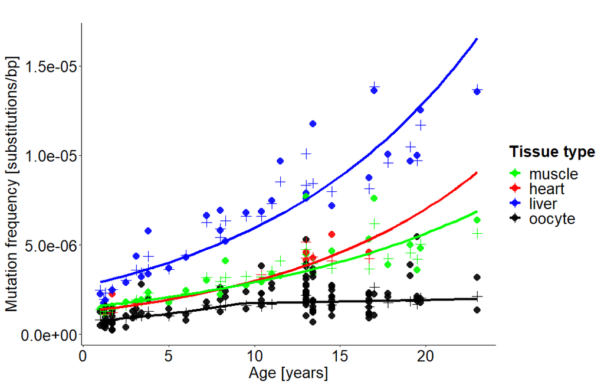

```r
options(repr.plot.width=11, repr.plot.height=7)

age_plot = seq(min(mut$age_years),max(mut$age_years),length.out = 50)
data_plot = data.frame(tissue = rep(levels(mut$tissue), each=50),
                       age_years = rep(age_plot, 4),
                       age_years_scaled = rep((age_plot-mean(mut$age_years))/sd(mut$age_years), 4))
data_plot$age_break_var = ( data_plot$age_years_scaled > age_break_scaled ) * ( data_plot$age_years_scaled - age_break_scaled ) * ( data_plot$tissue == "oocyte" )
data_plot$mut_freq = predict(glmer_results_break, data_plot, re.form=~0, type='response')

p <- ggplot(mut, aes(x=age_years, y=mut_freq, color=tissue)) +
  geom_point(shape=16, size=4, alpha=0.9) +
  scale_color_manual(values=c("green", "red","blue", "black")) +
  theme_classic() +
  labs(title="",x="Age [years]",y="Mutation frequency [substitutions/bp]") +
  theme(axis.text.x = element_text(size=20, color="black"),axis.text.y = element_text(size=20, color="black"), axis.title.x = element_text(size=20), axis.title.y = element_text(size=20)) +
  guides(color=guide_legend(title="Tissue type")) +
  theme(legend.text=element_text(size=20)) +
  theme(legend.title=element_text(size=20, face="bold")) +
  theme(plot.title = element_text(size=20, lineheight=.8, face="bold", hjust = 0.5)) +

  geom_point(mut, mapping = aes(x = age_years, y = fitted(glmer_results), color=tissue), shape = 3, size = 4) +
  geom_line(data_plot, mapping = aes(x = age_years, y = mut_freq, color=tissue), lwd = 1.5)

ggsave(filename="2021-04-03_mut_freq_d100_model_pred_breakAIC_oocyte.pdf", plot=p, , width = 11, height = 7)

p
```

```r
age_plot = seq(min(mut$age_years),max(mut$age_years),length.out = 50)
data_plot = data.frame(tissue = rep(levels(mut$tissue), each=50),
                       age_years = rep(age_plot, 4),
                       age_years_scaled = rep((age_plot-mean(mut$age_years))/sd(mut$age_years), 4))
data_plot$age_break_var = ( data_plot$age_years_scaled > age_break_scaled ) * ( data_plot$age_years_scaled - age_break_scaled ) * ( data_plot$tissue == "oocyte" )
data_plot$mut_freq = predict(glmer_results_break, data_plot, re.form=~0, type='response')

# bootstrap for computing CI using quantile approach
predFun <- function(fit){
  predict(fit, data_plot, re.form=~0, type='response')
}
merBoot = bootMer(glmer_results_break, FUN=predFun, nsim=100)
CIlevel = 0.95
data_plot$mut_freq_CIlower = apply(merBoot$t, 2, function(x) as.numeric(quantile(x, probs=(1-CIlevel)/2, na.rm=TRUE)))
data_plot$mut_freq_CIupper = apply(merBoot$t, 2, function(x) as.numeric(quantile(x, probs=(1+CIlevel)/2, na.rm=TRUE)))
```

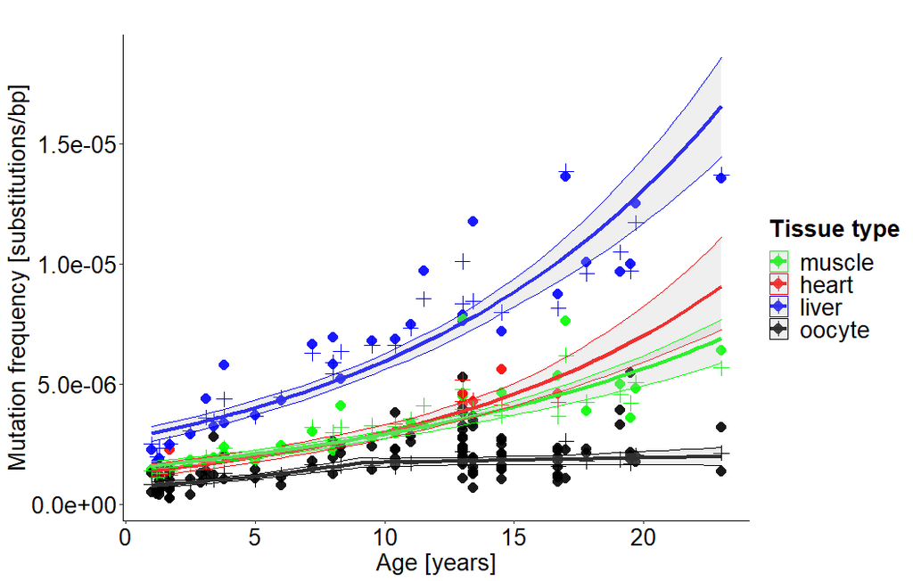

```r
options(repr.plot.width=11, repr.plot.height=7)

p <- ggplot(mut, aes(x=age_years, y=mut_freq, color=tissue)) +
  geom_point(shape=16, size=4, alpha=0.9) +
  scale_color_manual(values=c("green", "red","blue", "black")) +
  theme_classic() +
  labs(title="",x="Age [years]",y="Mutation frequency [substitutions/bp]") +
  theme(axis.text.x = element_text(size=20, color="black"),axis.text.y = element_text(size=20, color="black"), axis.title.x = element_text(size=20), axis.title.y = element_text(size=20)) +
  guides(color=guide_legend(title="Tissue type")) +
  theme(legend.text=element_text(size=20)) +
  theme(legend.title=element_text(size=20, face="bold")) +
  theme(plot.title = element_text(size=20, lineheight=.8, face="bold", hjust = 0.5)) +

  geom_point(mut, mapping = aes(x = age_years, y = fitted(glmer_results), color=tissue), shape = 3, size = 4) +
  geom_line(data_plot, mapping = aes(x = age_years, y = mut_freq, color=tissue), lwd = 1.5) +

  geom_ribbon(data_plot, mapping = aes(x=age_years, ymax=mut_freq_CIlower, ymin=mut_freq_CIupper), fill="gray", alpha=.25)

ggsave(filename="2021-12-23_mut_freq_d100_model_pred_breakAIC_oocyte_CI.pdf", plot=p, , width = 11, height = 7)

p
```

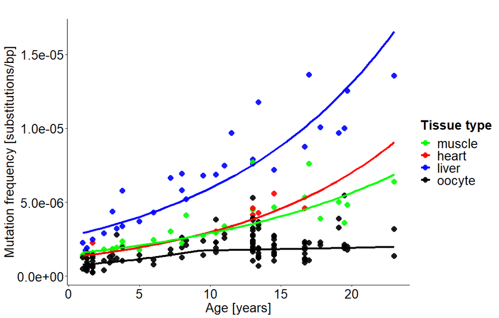

```r
options(repr.plot.width=11, repr.plot.height=7)

age_plot = seq(min(mut$age_years),max(mut$age_years),length.out = 50)
data_plot = data.frame(tissue = rep(levels(mut$tissue), each=50),
                       age_years = rep(age_plot, 4),
                       age_years_scaled = rep((age_plot-mean(mut$age_years))/sd(mut$age_years), 4))
data_plot$age_break_var = ( data_plot$age_years_scaled > age_break_scaled ) * ( data_plot$age_years_scaled - age_break_scaled ) * ( data_plot$tissue == "oocyte" )
data_plot$mut_freq = predict(glmer_results_break, data_plot, re.form=~0, type='response')

p <- ggplot(mut, aes(x=age_years, y=mut_freq, color=tissue)) +
  geom_point(shape=16, size=4, alpha=0.9) +
  scale_color_manual(values=c("green", "red","blue", "black")) +
  theme_classic() +
  labs(title="",x="Age [years]",y="Mutation frequency [substitutions/bp]") +
  theme(axis.text.x = element_text(size=20, color="black"),axis.text.y = element_text(size=20, color="black"), axis.title.x = element_text(size=20), axis.title.y = element_text(size=20)) +
  guides(color=guide_legend(title="Tissue type")) +
  theme(legend.text=element_text(size=20)) +
  theme(legend.title=element_text(size=20, face="bold")) +
  theme(plot.title = element_text(size=20, lineheight=.8, face="bold", hjust = 0.5)) +

  #geom_point(mut, mapping = aes(x = age_years, y = fitted(glmer_results), color=tissue), shape = 3, size = 4) +
  geom_line(data_plot, mapping = aes(x = age_years, y = mut_freq, color=tissue), lwd = 1.5)

ggsave(filename="2021-04-03_mut_freq_d100_model_pred_breakAIC_oocyte_no_plus.pdf", plot=p, , width = 11, height = 7)

p
```